# NYCFlights: Arrival Delay Regression Model

Shaofeng Deng

October 18, 2016

# NYCFlights Model

Using the rectangular data that you created last week and following the *Predicting Medical Expenses* example from the text (*MLwR*), create a model for arr_delay. Follow MLwR structure for building a model. Describe/Explain each of the steps and show all work in codeblocks below.

## Step 1: Collect Data

```r
YX <- read.csv("YX.csv",stringsAsFactors = T)
# Remove all observation with missing values
YX <- YX[complete.cases(YX),]
# Remove varibles with only one value or level
YX <- Filter(function(x)(length(unique(x))>1), YX)
```

## Step 2: Explore and Prep The Data

One of the things not done in the MLwR text is a pairwise comparison between the response and each of the predictors. Make sure to do this; this is often very illustrative of the relationship between that predictor and the response. This can be done with `pairs` or `psych::panel.pairs`

```r
# Confirm the format of the data
str(YX)
```

```
## 'data.frame':    781 obs. of  47 variables:
##  $ X             : int  167 318 407 706 770 847 1107 1435 1695 2010 ...
##  $ month         : int  1 1 1 1 1 1 1 1 1 1 ...
##  $ day           : int  1 1 1 1 1 2 2 2 2 3 ...
##  $ dep_time      : int  858 1219 1422 1911 2030 535 945 1603 2025 909 ...
##  $ sched_dep_time: int  900 1220 1410 1910 2045 540 945 1605 2015 700 ...
##  $ dep_delay     : int  -2 -1 12 1 -15 -5 0 -2 10 129 ...
##  $ arr_time      : int  1102 1415 1613 2050 2150 831 1113 1817 2216 1103 ...
##  $ sched_arr_time: int  1110 1415 1555 2055 2225 850 1130 1750 2210 850 ...
##  $ arr_delay     : int  -8 0 18 -5 -35 -19 -17 27 6 133 ...
##  $ carrier       : Factor w/ 16 levels "9E","AA","AS",..: 10 2 10 10 2 2 2 10 10 2 ...
##  $ flight        : int  4478 1757 4491 4569 371 1141 319 4415 4555 305 ...
##  $ tailnum       : Factor w/ 4043 levels "D942DN","N0EGMQ",..: 2930 1992 2930 2930 1992 2406 1992 2930 2930 433 ...
##  $ origin        : Factor w/ 3 levels "EWR","JFK","LGA": 3 3 3 3 3 2 3 3 3 3 ...
##  $ dest          : Factor w/ 105 levels "ABQ","ACK","ALB",..: 33 98 23 81 70 59 70 81 25 70 ...
```

[output cut: 33 more lines]

```r
# Summary of the responce
YX$arr_delay %>% summary
```

```
##    Min. 1st Qu.  Median    Mean 3rd Qu.    Max.
## -54.000 -18.000  -5.000   3.831  11.000 348.000
```

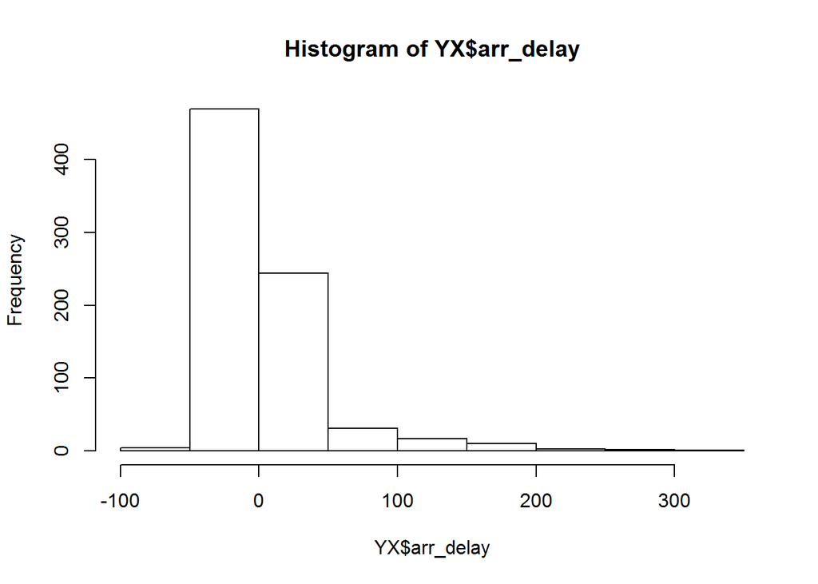

```r
# Histogram of the responce
hist(YX$arr_delay)
```

```r
# Corrolations between dependent varible and other varibles
nums <- sapply(YX, is.numeric)
co <- YX[nums] %>% cor(use="complete.obs")
co["arr_delay",]
```

```
##              X          month            day       dep_time sched_dep_time
##   -0.054729353   -0.041353579   -0.026996813    0.199480608    0.070908162
##      dep_delay       arr_time sched_arr_time      arr_delay         flight
##    0.894986382    0.196035183    0.065935721    1.000000000    0.053194005
##       air_time       distance           hour         minute           temp
##    0.055280215    0.022000816    0.072641771   -0.049826908   -0.001026882
##           dewp          humid       wind_dir     wind_speed      wind_gust
##    0.002099771    0.008737249   -0.018686523    0.038430494    0.038430459
##         precip       pressure          visib         year.y        engines
##    0.048043303   -0.036097328   -0.060913261    0.040977646   -0.043337555
##          seats          speed          lat.x          lon.x          alt.x
##   -0.053319702   -0.048657712   -0.070102058    0.015580751   -0.075590708
##          lat.y          lon.y          alt.y           tz.y
##   -0.007304819   -0.030049732    0.076642390   -0.040472784
```

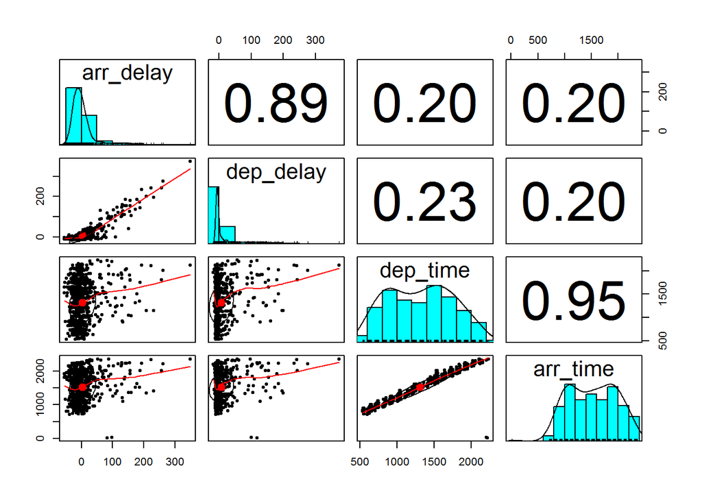

```r
# Use the most corrolated varibles to compute scatterplot matrix
psych::pairs.panels(YX[c("arr_delay", "dep_delay", "dep_time", "arr_time")])
```